# 0. Введение

## 3.2 Как данные разделяются между друг другом?

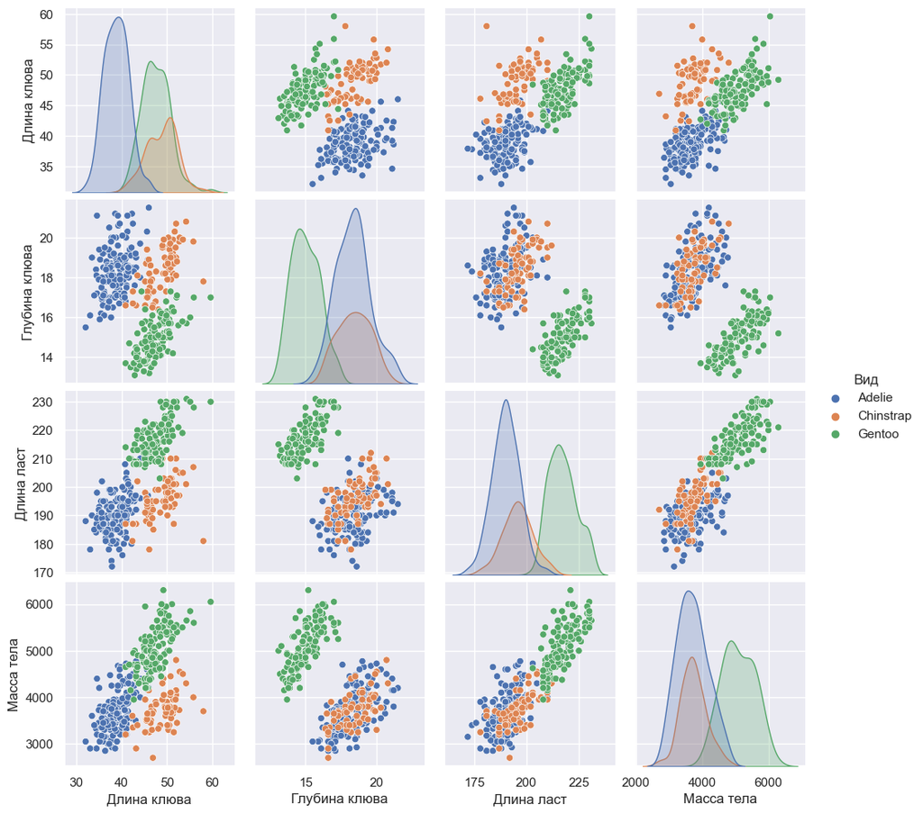

```python
sns.set(style='darkgrid')
sns.pairplot(data=df, hue='Вид')
plt.show()
```

# 4. Кодирование

## 4.1 Поиск колонок, содержащих текст

```python
# нахождение всех колонок с типом данных object
text_columns = df.select_dtypes(exclude='number').columns

column = []
value = []

for col in text_columns:
    unique = df[col].unique()
    unique = ', '.join(unique)

    column.append(col)
    value.append(unique)

un_dict = {'Назв. колонок': column, 'Уник. значения': value}
un_df = pd.DataFrame(un_dict)

un_df['Кол-во уник. значений'] = un_df['Уник. значения'].apply(lambda x: len(set(x.split(', '))))
un_df.set_index('Назв. колонок', inplace=True)

un_df
```

| Назв. колонок | Уник. значения | Кол-во уник. значений |
| --- | --- | --- |
| Вид | Adelie, Chinstrap, Gentoo | 3 |

## 4.2 Кодирование колонки "Вид"

```python
df['Вид'] = pd.factorize(df['Вид'])[0]
df.head()
```

|  | Длина клюва | Глубина клюва | Длина ласт | Масса тела | Вид |
| --- | --- | --- | --- | --- | --- |
| 0 | 39.1 | 18.7 | 181.0 | 3750.0 | 0 |
| 1 | 39.5 | 17.4 | 186.0 | 3800.0 | 0 |
| 2 | 40.3 | 18.0 | 195.0 | 3250.0 | 0 |
| 4 | 36.7 | 19.3 | 193.0 | 3450.0 | 0 |
| 5 | 39.3 | 20.6 | 190.0 | 3650.0 | 0 |

# 5. Создание модели Decision Trees

## 5.1 Создание модели

```python
from sklearn.model_selection import train_test_split

# разделение данных
target_var = 'Вид'
X = df.drop(target_var, axis=1)
y = df[target_var]
X_train, X_test, y_train, y_test = train_test_split(X, y, test_size=0.3, random_state=101)
```

```python
from sklearn.tree import DecisionTreeClassifier

model = DecisionTreeClassifier()
model.fit(X_train, y_train)
```

```
DecisionTreeClassifier()
```

## 5.2 Функция для оценки работы модели

```python
from sklearn.metrics import accuracy_score, precision_score, recall_score, f1_score, confusion_matrix, roc_auc_score, roc_curve, auc

def classification_metrics(model, X_test, y_test):

    y_pred = model.predict(X_test)

    # Точность (Accuracy)
    accuracy = round(accuracy_score(y_test, y_pred), 4)
    print(f'Accuracy: {accuracy}')

    # Precision
    precision = round(precision_score(y_test, y_pred, average='micro'), 4)
    print(f'Precision: {precision}')

    # Recall
    recall = round(recall_score(y_test, y_pred, average='micro'), 4)
    print(f'Recall: {recall}')

    # F1-score
    f1 = round(f1_score(y_test, y_pred, average='micro'), 4)
    print(f'F1-score: {f1}')

    # AUC
    auc_value = round(roc_auc_score(y_test, model.predict_proba(X_test), multi_class='ovr'), 4)
    print(f'AUC: {auc_value}\n')

    # Confusion Matrix
    cm = confusion_matrix(y_test, y_pred)
    cm_perc = np.round(cm / len(y_test) * 100, 2)

    print(f'Матрица ошибок:\n {cm}\n')
    print(f'Матрица ошибок в %:\n {cm_perc}\n')

    # ROC Curve
    n_classes = len(np.unique(y_test))

    # Инициализация пустого массива для хранения AUC для каждого класса
    auc_values = np.zeros(n_classes)

    plt.figure(figsize=(5, 5))
    sns.set(style='darkgrid')

    for i in range(n_classes):
        # Преобразование задачи в бинарную для каждого класса
        y_binary = (y_test == i).astype(int)

        fpr, tpr, _ = roc_curve(y_binary, model.predict_proba(X_test)[:, i])
        auc_values[i] = auc(fpr, tpr)

        plt.plot(fpr, tpr, label=f'ROC-кривая класса {i} (AUC = {auc_values[i]:.2f})')

    plt.plot([0, 1], [0, 1], 'k--', label='Случайное угадывание')

    plt.xlabel('Ложно положительные результаты')
    plt.ylabel('Истинно положительные результаты')
    plt.title('ROC-кривая для многоклассовой задачи')

    plt.legend(loc='lower right')
    plt.show()
```

## 5.3 Оценка важности каждого из признаков для классификации

```python
col = X.columns
value = model.feature_importances_
ser_params = pd.DataFrame(data=value, index=col, columns=['Важность признаков']).sort_values(by='Важность признаков', ascending=False)
ser_params
```

|  | Важность признаков |
| --- | --- |
| Длина ласт | 0.531201 |
| Длина клюва | 0.367818 |
| Глубина клюва | 0.052214 |
| Масса тела | 0.048767 |

```python
ser_params.sum()
```

```
Важность признаков    1.0
dtype: float64
```

```python
from sklearn.tree import plot_tree

def chart_tree(model):

    columns = X.columns.tolist()
    plt.figure(figsize=(12, 8), dpi=250)
    plot_tree(model, feature_names=columns, filled=True)
    plt.show()
```

```
Accuracy: 0.9604
Precision: 0.9604
Recall: 0.9604
F1-score: 0.9604
AUC: 0.9675

Матрица ошибок:
 [[39  2  0]
 [ 2 21  0]
 [ 0  0 37]]

Матрица ошибок в %:
 [[38.61  1.98  0.  ]
 [ 1.98 20.79  0.  ]
 [ 0.    0.   36.63]]
```

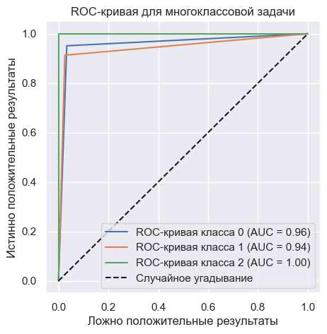

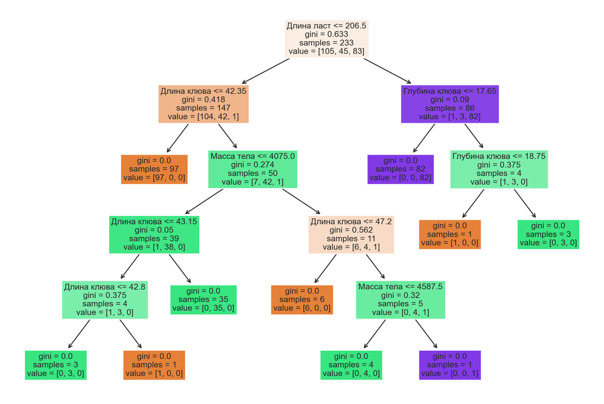

```python
classification_metrics(model, X_test, y_test)
chart_tree(model)
```

# 6. Сохрание модели

```python
# обучение модели на всём наборе данных
final_model = DecisionTreeClassifier()
final_model.fit(X, y)
```

```
DecisionTreeClassifier()
```

```python
from joblib import dump
import os

folder_path = 'E:\\Портфолио\\Классификация пингвинов с помощью Decision Trees'
file_path = os.path.join(folder_path, 'penguin_classif.joblib')

os.makedirs(folder_path, exist_ok=True)
dump(final_model, file_path)

print('Модель сохранена!')
```

```
Модель сохранена!
```

# 7. Импорт модели

```python
import joblib

# Указываем путь к папке и файлу
folder_path = 'E:\\Портфолио\\Классификация пингвинов с помощью Decision Trees\\'
file_name = 'penguin_classif.joblib'
file_path = folder_path + file_name

# Загружаем модель из файла
model = joblib.load(file_path)
print('Модель успешно импортирована!')
```

```
Модель успешно импортирована!
```

# 8. Использование модели

## 8.1 Функция для использования модели

```python
def penguin_classification(model, data):

    import warnings

    with warnings.catch_warnings():
        data = [data]
        warnings.simplefilter("ignore")
        result = model.predict(data)[0]
        probabilities = model.predict_proba(data)
        number = round(probabilities[0].max() * 100, 2)

    if result == 0:
        print(f'Данные принадлежит к классу: Adelie. Вероятность: {number}%')
    elif result == 1:
        print(f'Данные принадлежит к классу: Chinstrap. Вероятность: {number}%')
    else:
        print(f'Данные принадлежит к классу: Gentoo. Вероятность: {number}%')
```

## 8.2 Пример использования модели

```python
data = []

beak_length = float(input('Введите длину клюва ( мм ): '))
data.append(beak_length)

beak_depth = float(input('Введите глубину клюва ( мм ): '))
data.append(beak_depth)

fin_length = float(input('Введите длину ласт ( мм ): '))
data.append(fin_length)

body_mass = float(input('Введите массу тела ( гр ):'))
data.append(body_mass)

penguin_classification(model, data)
```

```
Введите длину клюва ( мм ): 35
Введите глубину клюва ( мм ): 16.8
Введите длину ласт ( мм ): 172.4
Введите массу тела ( гр ):3200
Данные принадлежит к классу: Adelie. Вероятность: 100.0%
```

# 9. Вывод

### Модель демонстрирует высокую эффективность классификации данных, подтвержденную следующими метриками: Accuracy (Точность) составляет 96.04%, что указывает на общую точность модели; Precision (Точность) и Recall (Полнота) также оцениваются на уровне 96.04%, что свидетельствует о высокой точности и способности модели обнаруживать положительные случаи. Значение F1-score (F1-мера) равное 0.9604 говорит о сбалансированности модели между Precision и Recall. Кроме того, AUC (Площадь под ROC-кривой) составляет 0.9675, что также подтверждает высокую способность модели различать классы. Матрица ошибок показывает, что модель редко делает ошибки, что подтверждает ее эффективность в классификации данных.